# Regressing IMDB Ratings

Zubair Lalani, Saurav Sharma, David Moreno

2024-12-11

# Preface for the Professor

Our original proposal was built around a Stress-related dataset which, through exploration, we realized was generated in a uniformly distributed manner. This proved impossible for us to get meaningful insights from it and resulted in us changing direction to use this IMDB dataset.

# Introduction

In today’s world, films span a wide range of genres, ratings, and certifications, and online platforms like IMDb serve as a hub where viewers rate and discuss these titles. Understanding what features might influence a film’s rating can be valuable for researchers, the film industry, and enthusiasts alike. Are movies with certain content advisories (such as strong violence or profanity) associated with higher or lower viewer ratings? Does the level of audience engagement, as measured by the number of votes cast, correlate with the final rating a film receives? Furthermore, how might genre or other attributes help us model and predict a film’s average IMDb rating?

To explore these questions, we will analyze a dataset derived from IMDb listings. This dataset includes films along with their IMDb ratings, number of votes, runtime, certification rating, and several qualitative content advisories (e.g., for nudity, violence, profanity, alcohol use, and frightening elements). It also includes genre information, which is provided as multiple genres associated with each title. Our goal is to build a regression model that helps explain and predict the IMDb rating of a film based on these characteristics.

We obtained the data from an IMDb dataset that compiles various features of films and television episodes. For this project, we focus only on feature films and exclude television episodes to ensure a more uniform set of observations. After data cleaning and preprocessing, we will examine relationships between IMDb rating and predictors like the number of votes, content advisories, duration, certification rating, and the presence or absence of certain genres. Since IMDb ratings are widely recognized by both casual viewers and industry professionals, a model that can successfully characterize these ratings may provide insights into patterns behind audience reception. The final aim is not to arrive at a single “correct” model, but rather to use the tools from our regression analysis toolkit – such as transformations, dummy variables, residual diagnostics, and model selection – to develop a model that fits the data well, checks standard regression assumptions, and ultimately offers meaningful interpretation in the context of film rating prediction.

# Methods

To create a suitable predictive model, we followed a systematic approach that involved data preparation, exploratory analysis, and iterative model fitting. We began by loading the dataset (imdb.csv) and performing initial checks on its structure and contents.

```r
imdb_data = read.csv("imdb.csv", header=TRUE)
str(imdb_data)
```

```
## 'data.frame':    6178 obs. of  14 variables:
##  $ Name       : chr  "No Time to Die" "The Guilty" "The Many Saints of Newark" "Venom: Let There Be Carnage" ...
##  $ Date       : int  2021 2021 2021 2021 2021 2021 2021 2021 2021 2021 ...
##  $ Rate       : chr  "7.6" "6.3" "6.4" "6.4" ...
##  $ Votes      : chr  "107,163" "64,375" "27,145" "30,443" ...
##  $ Genre      : chr  "Action, Adventure, Thriller" "Crime, Drama, Thriller" "Crime, Drama" "Action, Adventure, Sci-Fi" ...
##  $ Duration   : chr  "163 " "90 " "120 " "97 " ...
##  $ Type       : chr  "Film" "Film" "Film" "Film" ...
##  $ Certificate: chr  "PG-13" "R" "R" "PG-13" ...
##  $ Episodes   : chr  "-" "-" "-" "-" ...
##  $ Nudity     : chr  "Mild" "None" "Moderate" "None" ...
##  $ Violence   : chr  "Moderate" "None" "Severe" "Moderate" ...
##  $ Profanity  : chr  "Mild" "Severe" "Severe" "Moderate" ...
##  $ Alcohol    : chr  "Mild" "None" "Moderate" "Mild" ...
##  $ Frightening: chr  "Moderate" "Moderate" "Moderate" "Moderate" ...
```

The original dataset included various observations of films and television episodes, along with attributes such as IMDb rating, number of votes, genre listing, and content advisories. Our first task was to ensure data quality, which include:

## Filtering and Cleaning

We removed rows with missing values to maintain the integrity of our analysis.

```r
imdb_data = na.omit(imdb_data)

imdb_data = subset(imdb_data, Rate != "No Rate")
imdb_data = subset(imdb_data, Nudity != "No Rate")
imdb_data = subset(imdb_data, Violence != "No Rate")
imdb_data = subset(imdb_data, Profanity != "No Rate")
imdb_data = subset(imdb_data, Alcohol != "No Rate")
imdb_data = subset(imdb_data, Frightening != "No Rate")
```

We excluded television episodes and focused solely on feature films, removing any variables (such as episode count and type indicators) that were no longer relevant.

```r
imdb_data = subset(imdb_data, Type == "Film")
imdb_data = subset(imdb_data, select = -c(Episodes, Type)) # only considering films so episode count and type (series or film) not needed
```

We addressed duplicates in the data, retaining only unique films to avoid skewing results with repeated entries.

```r
imdb_data = imdb_data[!duplicated(imdb_data), ]
```

We also converted variables to appropriate data types. For example, the ratings and votes were coerced into numeric form, while certifications and advisories were treated as factors.

```r
imdb_data$Rate = as.numeric(imdb_data$Rate)
imdb_data$Votes = as.numeric(gsub(",", "", imdb_data$Votes))
imdb_data$Duration = as.numeric(imdb_data$Duration)
imdb_data$Certificate = as.factor(imdb_data$Certificate)
imdb_data$Nudity = as.factor(imdb_data$Nudity)
imdb_data$Violence = as.factor(imdb_data$Violence)
imdb_data$Profanity = as.factor(imdb_data$Profanity)
imdb_data$Frightening = as.factor(imdb_data$Frightening)
```

## Data Transformation and Feature Engineering

The Genre variable was provided as a comma-separated string (e.g., “Adventure, Drama, Fantasy”). To include genre information in a regression framework, we transformed this categorical data into multiple binary (dummy) variables, one for each unique genre.

```r
genres_list = strsplit(imdb_data$Genre, ", ")
unique_genres = unique(unlist(genres_list))

# also need to sanitize; can't have "Sci-Fi", should instead be "Sci.Fi"
for (genre in unique_genres) {
  imdb_data[[make.names(genre)]] = sapply(genres_list, function(genres) genre %in% genres)
}

# remove original Genre column from dataset
imdb_data = imdb_data[, !names(imdb_data) %in% "Genre"]
```

## Model Construction and Refinement

```r
set.seed(1234)
initial_model = lm(Rate ~ Duration + Certificate + Nudity + Violence + Profanity +
              Alcohol + Frightening + Action + Adventure + Thriller + Crime + Drama +
              Sci.Fi + Comedy + History + Fantasy + Horror + Mystery + Animation +
              Family + Romance + Western + Musical + Biography + Music + War +
              Sport + Short + Film.Noir + Documentary, data = imdb_data)
```

As expected, the results of our initial model were rather poor (see “Results” section for more details). Therefore, after doing some investigation, we decided to include 2 more predictors that we believe would improve the model. These predictors were “Votes” and “Date”. We applied a log transformation to “Votes” because it had a large range.

```r
set.seed(1234)
genre_terms = paste(make.names(unique_genres), collapse = " + ")
formula = as.formula(paste("Rate ~ log(Votes) + Date + Duration + Certificate + Nudity + Violence + Profanity + Alcohol + Frightening +", genre_terms))
#initial_model = lm(formula, data = imdb_data)
# CANNOT USE A FORMULA CREATED THIS WAY ^. Boxcox library will error out.

additive_model = lm(Rate ~ log(Votes) + Date + Duration + Certificate + Nudity + Violence + Profanity +
              Alcohol + Frightening + Action + Adventure + Thriller + Crime + Drama +
              Sci.Fi + Comedy + History + Fantasy + Horror + Mystery + Animation +
              Family + Romance + Western + Musical + Biography + Music + War +
              Sport + Short + Film.Noir + Documentary, data = imdb_data)
```

We defined a diagnostics helper function to easily determine if constraints are being satisfied.

```r
diagnostics = function(model, pcol = "grey", lcol = "dodgerblue", alpha = 0.05, plotit = TRUE, testit = TRUE) {
  output = list()
  if (testit) {
    shapiro_test = shapiro.test(residuals(model))
    p_val = shapiro_test$p.value
    decision = ifelse(p_val < alpha, "Reject", "Fail to Reject")
    output$p_val = p_val
    output$decision = decision
  }
  if (plotit) {
    par(mfrow = c(1, 2))
    plot(model$fitted.values, residuals(model),
         col = pcol, pch = 19,
         xlab = "Fitted", ylab = "Residuals",
         main = "Residuals vs Fitted")
    abline(h = 0, col = lcol, lwd=3)
    qqnorm(residuals(model), col = pcol, pch = 19, main = "Normal Q-Q Plot")
    qqline(residuals(model), col = lcol, lwd=3)
  }
  return(output)
}
```

```r
additive_model_summary = summary(additive_model)
diagnostics_result = diagnostics(additive_model)
```

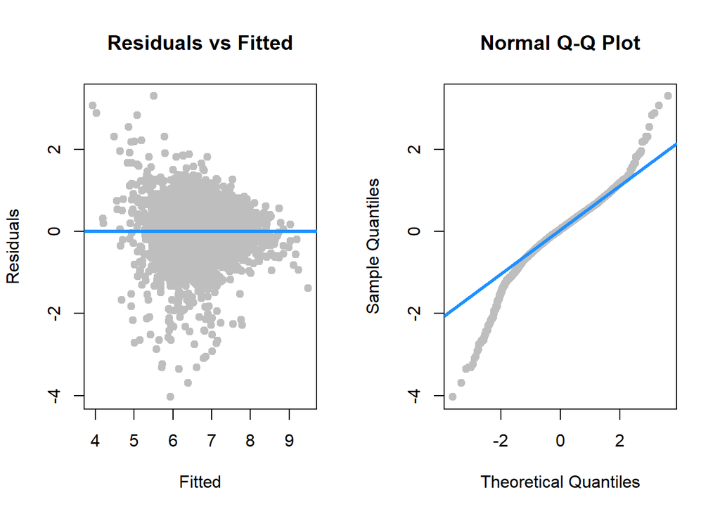

The diagnostics for our additive model were lukewarm. The `Residuals vs Fitted` showed a slight, but discernible, funnel shape. The `Normal Q-Q` plot showed deviations from the diagonal line at tail end of the lower-quantiles. This indicated that the residuals are not perfectly normally distributed. The Shapiro-Wilk test corroborated this finding, with a p-value of 7.3972076^{-31}, leading to the rejection of the null hypothesis of normality. Notably, the Adjusted R-Squared for this additive model was 0.5279519.

Given these results, we aimed to iteratively refine our model first by removing any influential points which might have impacted the fit of our initial model.

```r
set.seed(1234)
leverage = hatvalues(additive_model)
cooks_distance = cooks.distance(additive_model)

influential_points = which(cooks_distance > 4 / nrow(imdb_data))

imdb_data_cleaned = imdb_data[-influential_points, ]
model_without_influential_pts = lm(Rate ~ log(Votes) + Date + Duration + Certificate + Nudity + Violence + Profanity + Alcohol + Frightening + Action + Adventure + Thriller + Crime + Drama + Sci.Fi + Comedy + History + Fantasy + Horror + Mystery + Animation + Family + Romance + Western + Musical + Biography + Music + War + Sport + Short + Film.Noir + Documentary,
                                   data = imdb_data_cleaned)

model_without_influential_pts_summary = summary(model_without_influential_pts)
```

Removing influential points did not significantly change our diagnostic plots, and the Adjusted R-Squared of this new model was now 0.5425427.

Continuing our exploration, we evaluated transformations of the response to improve normality of residuals and better meet linear regression assumptions. Ultimately, we found Box-cox transformation of our response variable to improve our model in these regards.

```r
library(MASS)
set.seed(1234)

any(imdb_data_cleaned$Rate <= 0) # no shift needed if non-positive values
```

```
## [1] FALSE
```

```r
boxcox_result = boxcox(model_without_influential_pts, lambda = seq(-2, 2, by = 0.1))
```

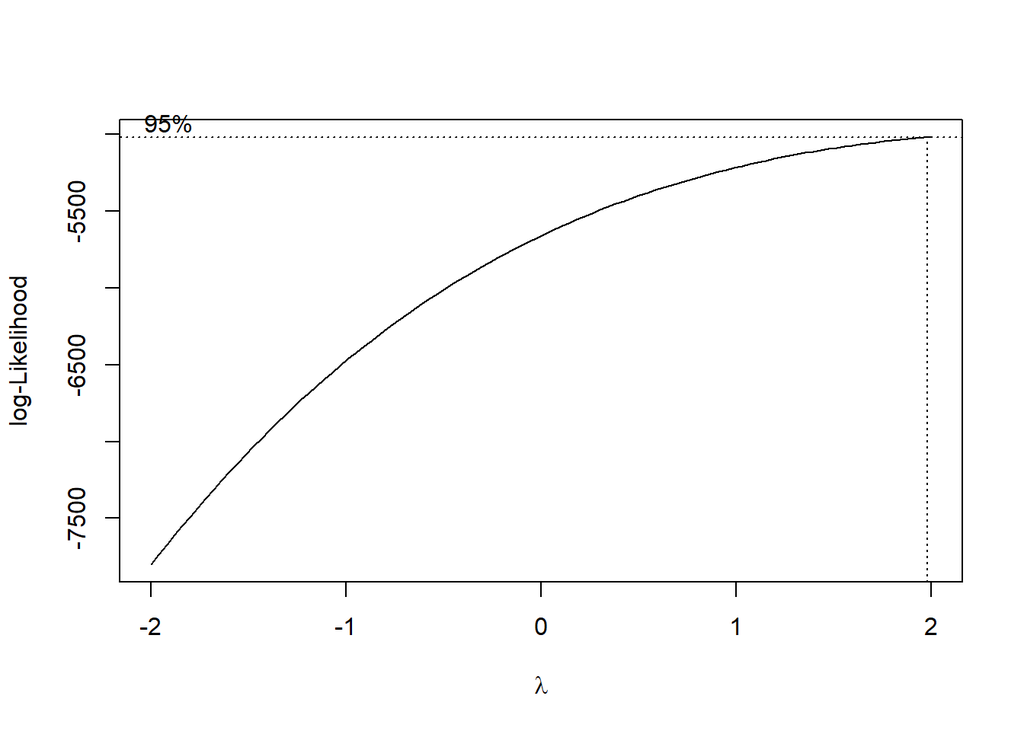

```r
optimal_lambda = boxcox_result$x[which.max(boxcox_result$y)]
imdb_data_cleaned$Rate_transformed = (imdb_data_cleaned$Rate^optimal_lambda - 1) / optimal_lambda

boxcox_transformed_model = lm(Rate_transformed ~ log(Votes) + Date + Duration + Certificate + Nudity + Violence
                       + Profanity + Alcohol + Frightening + Action + Adventure + Thriller +
                       Crime + Drama + Sci.Fi + Comedy + History + Fantasy + Horror + Mystery +
                       Animation + Family + Romance + Western + Musical + Biography + Music +
                       War + Sport + Short + Film.Noir + Documentary,
                       data = imdb_data_cleaned)

boxcox_transformed_model_summary = summary(boxcox_transformed_model)
```

The Boxcox transformation on the response variable seemed to have a decent impact on the diagnostics of our model.

We next reviewed variance inflation factors (VIFs) to check for multicollinearity issues and considered interaction terms where conceptually meaningful (e.g., between certain advisory categories and film genres).

```r
car::vif(boxcox_transformed_model)
```

```
##                  GVIF Df GVIF^(1/(2*Df))
## log(Votes)   1.550927  1        1.245362
## Date         1.653702  1        1.285964
## Duration     1.588122  1        1.260207
## Certificate 12.380731 18        1.072393
## Nudity       2.007385  3        1.123152
## Violence     6.275445  3        1.358128
## Profanity    3.507454  3        1.232628
## Alcohol      1.957441  3        1.118445
## Frightening  5.600925  3        1.332631
## Action       2.121345  1        1.456484
## Adventure    2.176024  1        1.475135
## Thriller     1.685458  1        1.298252
## Crime        1.524660  1        1.234771
## Drama        2.223447  1        1.491123
## Sci.Fi       1.397861  1        1.182312
## Comedy       2.397601  1        1.548419
## History      1.233619  1        1.110684
## Fantasy      1.311129  1        1.145045
## Horror       2.445732  1        1.563884
## Mystery      1.342102  1        1.158491
## Animation    1.921305  1        1.386112
## Family       1.574387  1        1.254746
## Romance      1.589441  1        1.260730
## Western      1.111068  1        1.054072
## Musical      1.061764  1        1.030419
## Biography    1.334887  1        1.155373
## Music        1.071972  1        1.035361
## War          1.103669  1        1.050557
## Sport        1.094451  1        1.046160
## Short        1.043384  1        1.021462
## Film.Noir    1.180521  1        1.086518
## Documentary  1.064504  1        1.031748
```

From this, we decided that it might be worth dropping a feature which seemed to be contributing to collinearity – namely `Certificate`.

Additionally, we believed that the relationship between some of our predictor variables would be better modeled as interactions rather than just additively. For example, we believed that the feature of `Frightening` would be better suited when associated with the `Horror` genre. Additionally, we combined `Alcohol`, `Nudity`, `Violence`, and `Profanity` through interaction as we believed that this interaction could account for the `Certificate` feature which we removed due to collinearity issues.

```r
set.seed(1234)
interaction_model = lm(Rate_transformed ~ log(Votes) + Date + Duration + (Nudity + Violence + Profanity + Alcohol)^2 + Frightening:Horror + Action + Adventure + Thriller +
                       Crime + Drama + Sci.Fi + Comedy + Fantasy + Horror + Mystery +
                       Animation + Family + Romance + Western + Musical + Biography + Music +
                       War + Sport + Short + Film.Noir + Documentary,
                       data = imdb_data_cleaned)

interaction_model_summary = summary(interaction_model)
```

With the awareness that our model seemed to be getting larger in features, we decided to take one final approach in our iteration. We decided to use [backward] stepwise selection to see if a reduced model fit equally or better.

```r
step_reduced_model = step(interaction_model, direction = "backward")
step_reduced_model_summary = summary(step_reduced_model)
```

Throughout this process, we documented each step of the analysis. We emphasize that our approach is not about applying every possible method, but rather about using appropriate methods to arrive at a well-justified final model that addresses a meaningful question: How well can we predict and explain a film’s IMDb rating using its measurable attributes?

# Results

Below you can find an assessment of the models we tried. The order of each section match our approach chronologically. Note that this is a subset of the models we tried as we added/removed predictors along the way as we experimented. This subset gives the best overall picture of our investigation and documents the results of major adjustments to our model.

## Initial additive model

*Adjusted R-Square:* 0.2901135

```r
initial_model_diagnostics = diagnostics(initial_model)
```

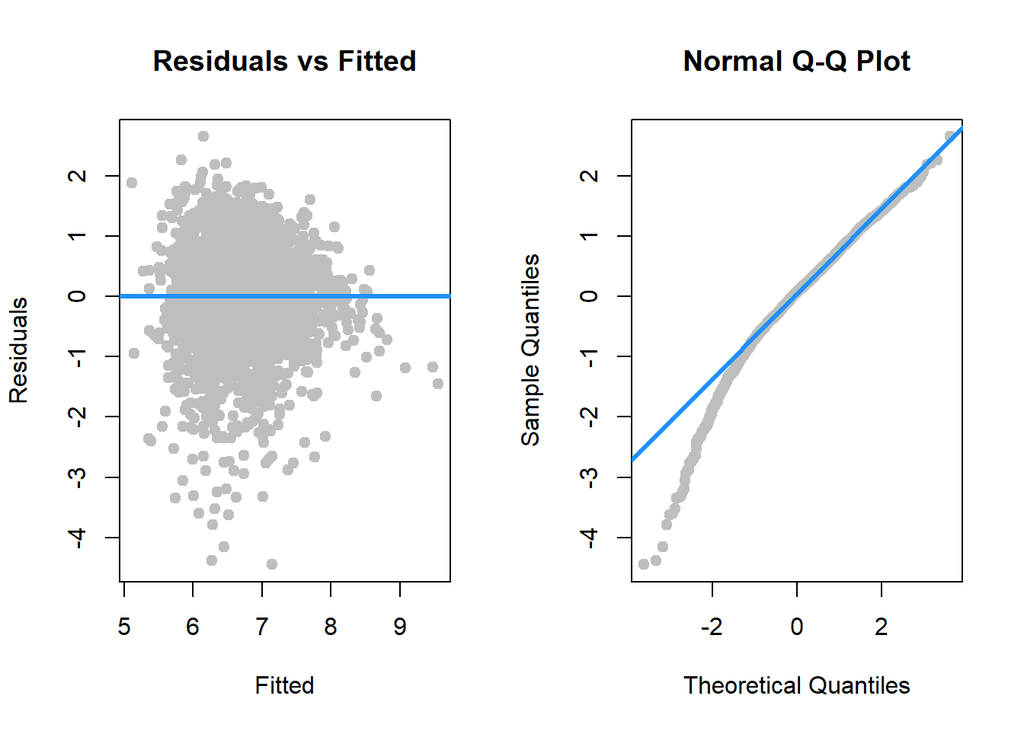

## Additive Model Results

*Adjusted R-Square:* 0.5279519

```r
additive_model_diagnostics = diagnostics(additive_model)
```

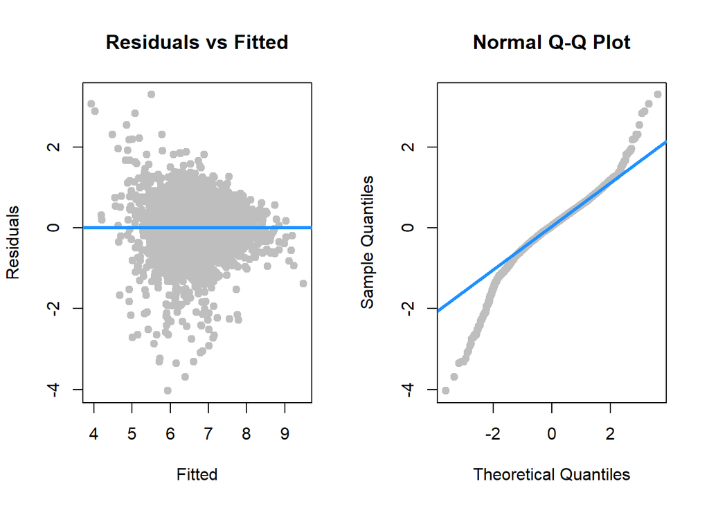

## Model without influential points

*Adjusted R-Square:* 0.5425427

```r
model_without_influential_diagnostics = diagnostics(model_without_influential_pts)
```

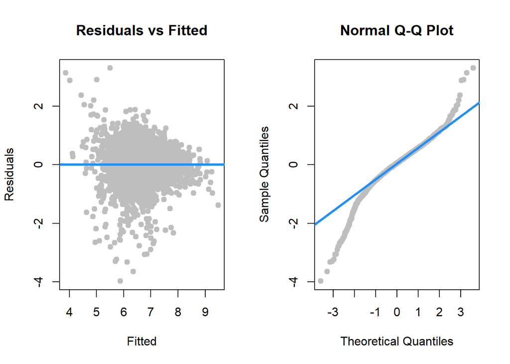

## Model with Box-Cox transformation applied

*Adjusted R-Square:* 0.5729902

```r
box_cox_mdl_diagnostics = diagnostics(boxcox_transformed_model)
```

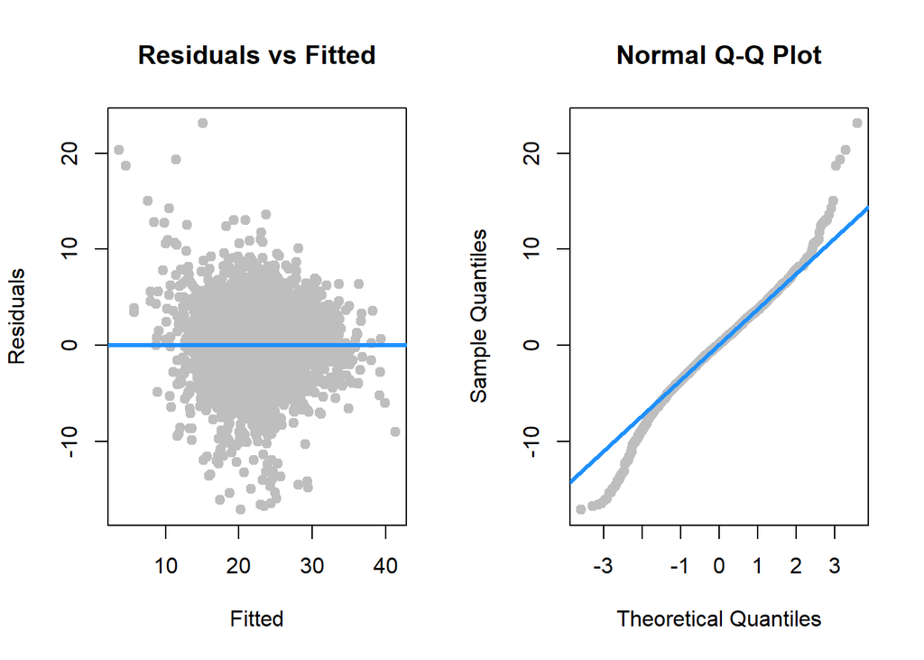

## Interaction Model (and remove variables to fix collinearity issues)

*Adjusted R-Square:* 0.5595744

```r
interaction_model_diagnostics = diagnostics(interaction_model)
```

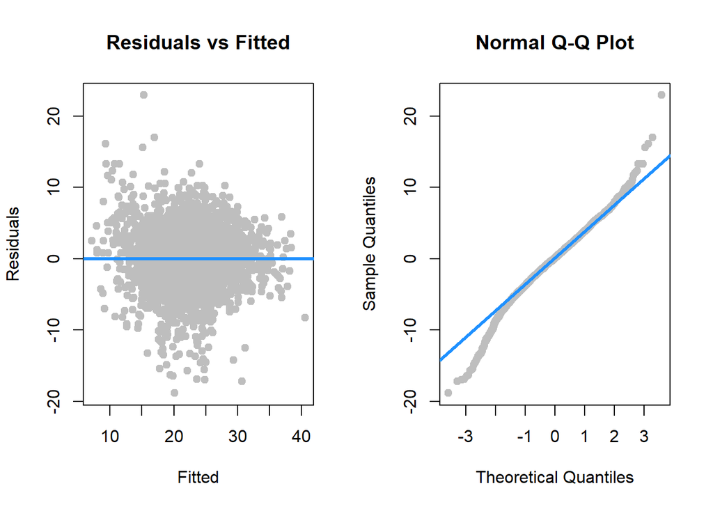

## Backward stepwise selection model

*Adjusted R-Square:* 0.560764

```r
step_reduced_model_diagnostics = diagnostics(step_reduced_model)
```

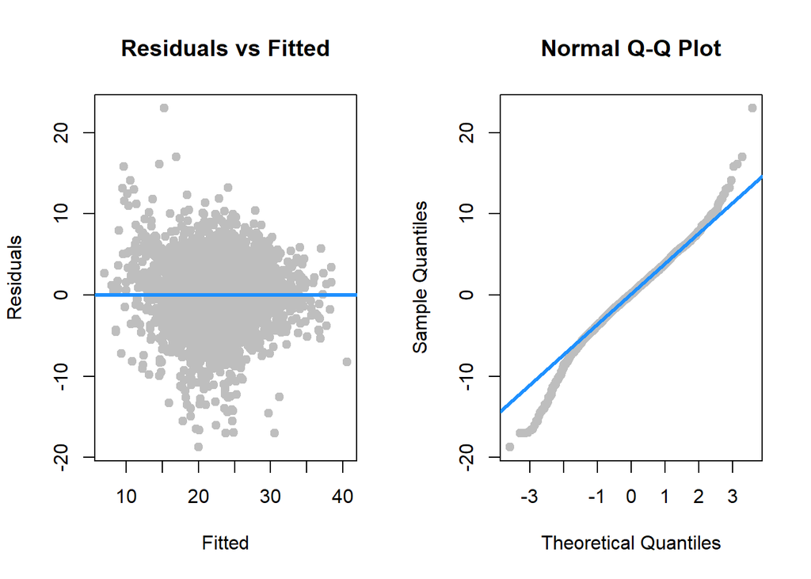

## Selecting a model

Based on the results above, we ultimately landed on our model that used backward selection as it had a good adjusted R Squared value, least number of predictors, while also having the best diagnostic plots. Below, we have displayed the formula for our final regression model.

```r
summary(step_reduced_model)$call
```

```
## lm(formula = Rate_transformed ~ log(Votes) + Date + Duration +
##     Nudity + Violence + Profanity + Action + Adventure + Thriller +
##     Drama + Sci.Fi + Comedy + Fantasy + Horror + Animation +
##     Family + Romance + Western + Biography + War + Short + Documentary +
##     Nudity:Violence + Nudity:Profanity + Violence:Profanity +
##     Horror:Frightening, data = imdb_data_cleaned)
```

This isn’t a perfect model, but we feel reasonably confident that this model provides solid information regarding what factors impact a film’s rating. Given that the data lacks some key informative predictors such as information regarding the cast/director of the movie, we believe that this model performs reasonably well compared to other models.

To illustrate this, we compare our prediction ability from our starting model to the final model we chose.

```r
set.seed(391993)

# split data
train_index = sample(seq_len(nrow(imdb_data_cleaned)), size = 0.85 * nrow(imdb_data_cleaned))
train_data = imdb_data_cleaned[train_index, ]
test_data = imdb_data_cleaned[-train_index, ]

# Retraining models in question using only train_data to prevent data leakage.
trained_initial_model = lm(Rate ~ Duration + Certificate + Nudity + Violence + Profanity +
              Alcohol + Frightening + Action + Adventure + Thriller + Crime + Drama +
              Sci.Fi + Comedy + History + Fantasy + Horror + Mystery + Animation +
              Family + Romance + Western + Musical + Biography + Music + War +
              Sport + Short + Film.Noir + Documentary, data = train_data)

trained_semifinal_model = lm(Rate_transformed ~ log(Votes) + Date + Duration + (Nudity + Violence + Profanity + Alcohol)^2 + Frightening:Horror + Action + Adventure + Thriller +
                       Crime + Drama + Sci.Fi + Comedy + Fantasy + Horror + Mystery +
                       Animation + Family + Romance + Western + Musical + Biography + Music +
                       War + Sport + Short + Film.Noir + Documentary,
                       data = train_data)
trained_final_model = step(trained_semifinal_model, direction = "backward")

# predict for both
predictions_initial = predict(trained_initial_model, newdata=test_data)
predictions_final = predict(trained_final_model, newdata=test_data)

# compare RMSEs
expected = test_data$Rate_transformed
rmse_value_initial_model = sqrt(mean((expected - predictions_initial)^2))
rmse_value_final_model = sqrt(mean((expected - predictions_final)^2))

rmse_value_initial_model
rmse_value_final_model
```

# Discussion

This project aimed to explore how various factors influence IMDb film ratings. We examined predictors such as the number of votes, genre, and content-related advisories, applying a series of transformations, interactions, and model selection techniques to refine our regression models.

While we did not achieve a “perfect” model, the process itself was instructive. It highlighted the importance of thoughtful data preparation, careful assumption checks, and iterative refinement for regression analysis. Future work could build on these findings by introducing additional predictors or experimenting with alternative modeling frameworks.